# Assignment2

Yu Tang

2025-08-20

## data load

```r
library(readxl)
library(tidyverse)
nameless <- read_xlsx("electorate_profiles_2020-data_file.xlsx", sheet="Percent", range = readxl::cell_limits(c(6, 2), c(NA, NA)), col_names=FALSE)#GPT
namestuff <- read_xlsx("electorate_profiles_2020-data_file.xlsx",sheet="Percent",range="B4:UH5",col_names=FALSE)
electorate_col <- read_xlsx("electorate_profiles_2020-data_file.xlsx", sheet = "Percent", range = "A6:A79", col_names = "electorate") |> drop_na()
```

## excel data cleaning

```r
top    <- unlist(namestuff[1, ])
bottom <- unlist(namestuff[2, ])
clean_names <- paste(top, bottom, sep = " ") |>
  str_squish()
demo <- bind_cols(electorate_col, setNames(nameless, clean_names))
```

## csv data cleaning

```r
library(janitor)
vote_data <- read_csv("votes2023.csv", show_col_types = FALSE) |>
  select(-1) |>
  clean_names() |>
  mutate(govt_total_votes =
           national_party + act_new_zealand + new_zealand_first_party)
str(vote_data)
```

```
## tibble [75 × 22] (S3: tbl_df/tbl/data.frame)
##  $ electorate                      : chr [1:75] "Auckland Central" "Banks Peninsula" "Bay of Plenty" "Botany" ...
##  $ act_new_zealand                 : num [1:75] 3301 3919 5212 2788 2646 ...
##  $ animal_justice_party            : num [1:75] 50 111 88 98 106 114 51 57 43 62 ...
##  $ aotearoa_legalise_cannabis_party: num [1:75] 142 182 193 106 174 223 185 159 164 105 ...
##  $ democracynz                     : num [1:75] 32 146 79 29 82 106 99 25 199 34 ...
##  $ freedoms_nz                     : num [1:75] 48 61 140 127 71 114 126 44 178 51 ...
##  $ green_party                     : num [1:75] 8503 9763 3635 2212 7746 ...
##  $ labour_party                    : num [1:75] 8028 13200 7905 7708 11357 ...
##  $ leighton_baker                  : num [1:75] 3 53 58 12 51 118 32 19 29 7 ...
##  $ national_party                  : num [1:75] 11751 15839 21452 22239 12403 ...
##  $ new_conservatives               : num [1:75] 30 62 56 86 78 175 43 94 56 58 ...
##  $ new_nation_party                : num [1:75] 26 22 24 37 36 24 19 18 20 24 ...
##  $ new_zealand_first_party         : num [1:75] 1351 2658 3957 1136 2073 ...
##  $ nz_loyal                        : num [1:75] 217 389 714 280 253 402 1580 402 546 386 ...
##  $ newzeal                         : num [1:75] 38 323 444 156 108 205 270 114 247 409 ...
##  $ te_pati_maori                   : num [1:75] 563 388 577 188 405 415 362 613 915 137 ...
##  $ the_opportunities_party_top     : num [1:75] 1250 2401 894 439 2042 ...
##  $ women_s_rights_party            : num [1:75] 45 42 24 27 59 46 32 35 25 32 ...
##  $ total_valid_party_votes         : num [1:75] 35378 49559 45452 37668 39690 ...
##  $ informal_party_votes            : num [1:75] 85 194 209 189 166 203 284 129 264 136 ...
##  $ total_party_votes_counted       : num [1:75] 35463 49753 45661 37857 39856 ...
##  $ govt_total_votes                : num [1:75] 16403 22416 30621 26163 17122 ...
```

```r
final_data <- demo |>
  inner_join(vote_data |>
               select(electorate, govt_total_votes), by="electorate")
```

## responable variable

```r
y <- final_data$govt_total_votes
X <- final_data |>
  select(-electorate, -govt_total_votes) |>
  mutate(across(where(is.character), as.factor)) |>
  mutate(across(where(is.factor), as.numeric)) |>
  as.matrix()
```

## Ridge Regression

```r
library(glmnet)
library(tidyr)
cv_ridge <- cv.glmnet(X, y, alpha = 0, standardize = TRUE)
dim(X)
```

```
## [1]  58 548
```

```r
summary(y)
```

```
##    Min. 1st Qu.  Median    Mean 3rd Qu.    Max.
##    2333   17466   22594   21571   27009   33047
```

```r
sd(y)
```

```
## [1] 7246.024
```

## plot 1

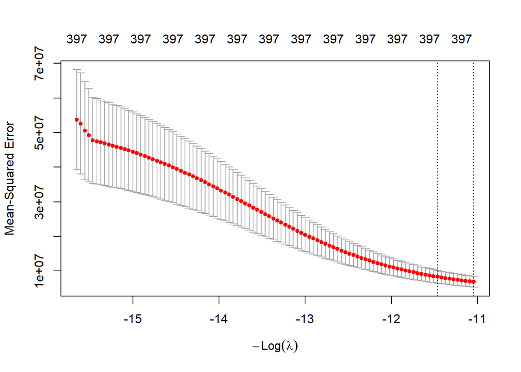

```r
fit <- cv.glmnet(X, y, alpha = 0, standardize = TRUE)
plot(fit)
```

```r
best_lambda <- fit$lambda.min
```

## plot 2

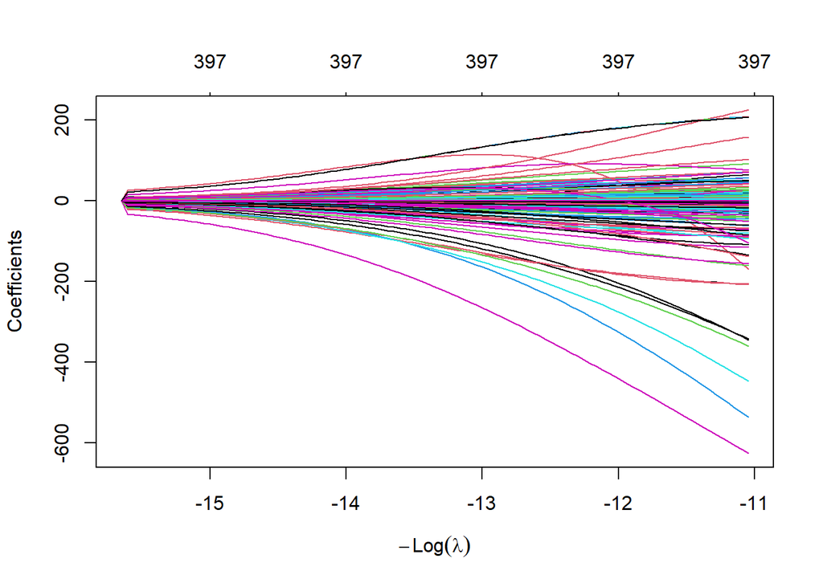

```r
xval <-glmnet(X,y, alpha = 0)
plot(xval)
```

## final model

```r
#coef(fit, s=xval$lambda.min)

ridge_model <- glmnet(X, y, alpha=0, lambda=best_lambda)

coef(ridge_model)
```

```
## 549 x 1 sparse Matrix of class "dgCMatrix"
##                                                                                                                                                                                                                                                              s0
## (Intercept)                                                                                                                                                                                                                                       1726.94636516
## Census usually resident population count 2006 Census                                                                                                                                                                                                 .
## Census usually resident population count 2013 Census                                                                                                                                                                                                65.23030617
## Census usually resident population count 2018 Census                                                                                                                                                                                                20.95299158
## Census night population count 2006 Census                                                                                                                                                                                                            .
## Census night population count 2013 Census                                                                                                                                                                                                            .
## Census night population count 2018 Census                                                                                                                                                                                                            .
## 2018 Census, unit record data source, for the census usually resident population count 2018 Census individual form                                                                                                                                   .
## 2018 Census, unit record data source, for the census usually resident population count Individuals on the household listing only                                                                                                                     .
## 2018 Census, unit record data source, for the census usually resident population count Admin enumeration                                                                                                                                             .
## 2018 Census, unit record data source, for the census usually resident population count Total                                                                                                                                                         .
## 2018 Census, sex, for the census usually resident population count Male                                                                                                                                                                             -1.15876013
## 2018 Census, sex, for the census usually resident population count Female                                                                                                                                                                            1.18706812
```

[output cut: 536 more lines]

## mse and rmse

```r
cv_mse <- min(cv_ridge$cvm)
cv_rmse <- sqrt(cv_mse)
cv_rmse
```

```
## [1] 2436.778
```

## prediction

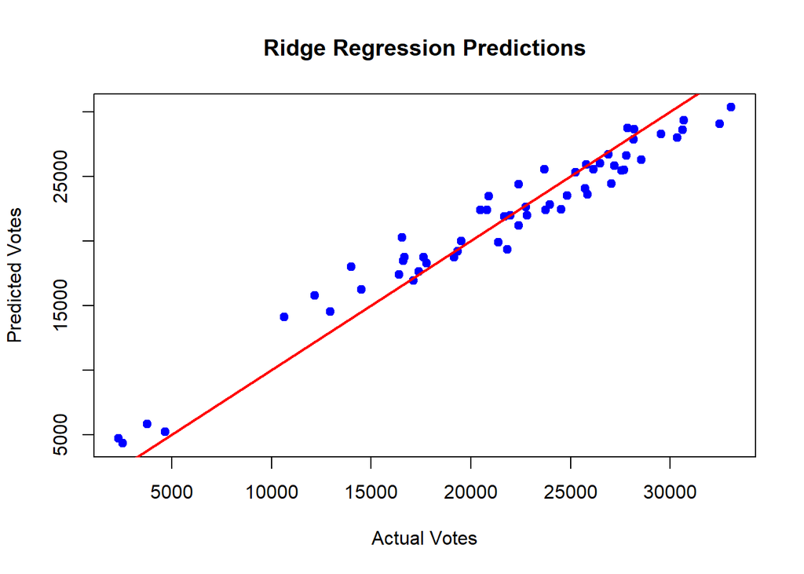

```r
y_pred <- predict(cv_ridge, s = "lambda.min", newx = X)
plot(y, y_pred,
     xlab = "Actual Votes", ylab = "Predicted Votes",
     main = "Ridge Regression Predictions",
     pch = 19, col = "blue")
abline(0, 1, col = "red", lwd = 2)
```

## report

### introduction

The purpose of this analysis is to build a predictive model for the total votes received by the three parties: National, ACT, and New Zealand First. We combine the data set electorate_profiles_2020-data_file.xlsx has demographic data for each New Zealand electorate, computed by Stats New Zealand for Parliament. And the data set votes2023.csv has the number of votes for each registered political party in each electorate. This report details the data preparation, modeling process, and evaluation of predictive performance using Ridge Regression.

### result

I applied 10-fold cross-validation (cv.glmnet) to select lambda. The best λ was chosen as the one minimizing MSPE. The cross-validation curve shows the relationship between λ and prediction error. The lambda.min was selected where the mean-squared error was minimized. The coefficient plot illustrates how predictor coefficients shrink as lambda increases. The scatter plot of predicted vs. actual government votes demonstrates that the model predictions closely follow the 45-degree line. The Ridge regression model achieved good predictive accuracy, with relatively low error at the chosen lambda according to the model fit. The predictions showed strong agreement with actual values, confirming the suitability of Ridge regression for this task.

## Citations and Acknowledgements

I have used chatgpt to load the data while choosing the range of the excel “range = readxl::cell_limits(c(6, 2), c(NA, NA))” to exclude the first column for easy combination of the whole table